# Penguin Sizes

Isabelle Rennenberg

# 1 Species and Relative Sizes

The following data includes size measurements for adult penguins from Palmer Station, Antarctica. To note, the body mass variable has been resized by 4000. The analysis of the data removed all missing variables, and sorted for penguins only found on the Biscoe and Torgersen islands. This removed the “Chinstrap” species completely from analysis. Finally, penguins with the body mass greater than 3500 and less than 5000 were included. This subset of the original data had 111 observations and 5 variables.

The following chart analyzes:

- **bill length**
- **flipper length**
- **body mass**

The first code chunk displays the creation of the data subset.

```r
penguin <- read.csv(file="https://isarenn.github.io/irennenberg/Week3/w03-penguins.csv")

penguin2 <- penguin[complete.cases(penguin),] #removing observations with missing values
penguin3 <- penguin2[penguin2$island %in% c('Torgersen','Biscoe'), ] #Only including penguins on the specific islands
penguin4 <- penguin3[penguin3$body_mass_g < 5000 & penguin3$body_mass_g > 3500, ] #only selecting penguins that meet the bodymass requirement
BMI <- (penguin4$body_mass_g)/4000 #Creating the BMI Variable
penguin5 <- subset(penguin4, select=-c(X,sex,year,body_mass_g)) #removing the unwanted variables

#doing the same with %>%

penguina <- penguin2 %>%
  filter(island == 'Biscoe' | island=='Torgersen') %>%
  filter( body_mass_g < 5000 & body_mass_g > 3500)

penguinb <- subset(penguina, select=-c(X,sex,year,body_mass_g)) #removing unwanted columns

#The two sets of coding both subset the original dataset in the same way. The dataset penguinb and penguin5 are identical. Penguin5 will be used for further analysis.
```

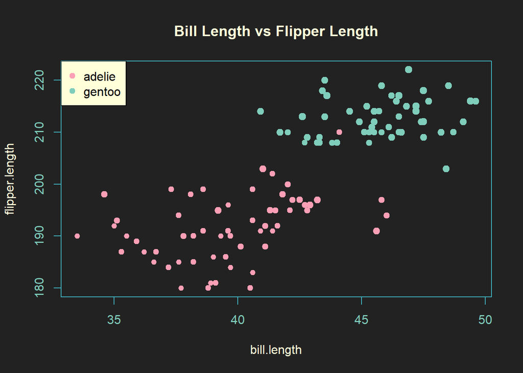

```r
penguin.img <- "https://isarenn.github.io/irennenberg/Week3/penguin2.png"
my.penguin <- readPNG(getURLContent(penguin.img))
raster.penguin <- as.raster(my.penguin)

bill.length <- penguin5$bill_length_mm
flipper.length  <- penguin5$flipper_length_mm

species <- penguin5$species

adelie.id = which(species=="Adelie")  # Here are our three species of penguin
gentoo.id = which(species=="Gentoo")

## color code
#  col.code = c(alpha("red",0.5),alpha("blue",0.5),alpha("cyan",0.5))
par(bg="#222222")

plot(bill.length, flipper.length, main = "Bill Length vs Flipper Length", col.main="#ffffd9", col.lab= "#ffffd9", col.ticks="#41b6c4", col.axis="#7fcdbb", type = "n")
box(col="#41b6c4")

points(bill.length[adelie.id], flipper.length[adelie.id],
       pch = 19, col = "#fa9fb5", cex = BMI[adelie.id], alpha = 0.1)
points(bill.length[gentoo.id], flipper.length[gentoo.id],
       pch = 19, col = "#7fcdbb", cex = BMI[gentoo.id], alpha = 0.1)
legend("topleft", c("adelie", "gentoo"),
                  border="#41b6c4",
                  bg="#ffffd9",
                  col=c("#fa9fb5", "#7fcdbb"),
                  pch=c(19, 19, 19))

rasterImage(raster.penguin,xleft=56,ybottom=185, xright=60, ytop=205)
text(45, 172.25, "The size is proportional to penguin body mass", col = "#ffffd9", cex = 1)
```

# 2 Chart Results

Based on the plot, it is visible that flipper length is highest for the gentoo penguins. The gentoo penguin bill length is larger than the adelie. The adelie penguins overall have a shorter flipper length and bill length. The bodymass of the gentoo is larger, as the size of the points on the plot are large. There are some crossovers in the middle of the plot, where both species have a couple penguins that are similar in flipper and bill length. Overall, the gentoo penguin separates itself in size for all three categories from the adelie penguin.